# Reproducible Research: Peer Assessment 1

## Loading and preprocessing the data

Read in the data, convert it into a format easy to work with and append new factor column.

```r
suppressPackageStartupMessages(library(dplyr))
library(ggplot2)
library(lubridate)
library(tidyr)
activity <- unz("activity.zip", "activity.csv") %>%
    read.csv() %>%
    tbl_df() %>%
    mutate(date=ymd(date)) %>%
    mutate(dayofweek = ifelse((wday(date) == 1 | wday(date) == 7),'weekend','weekday'))
```

## What is mean total number of steps taken per day?

```r
dailyActivity <- group_by(activity, date) %>%
    summarise(daysteps=sum(steps))
dailyMean <- mean(dailyActivity$daysteps, na.rm=TRUE)
dailyMedian <- median(dailyActivity$daysteps, na.rm=TRUE)
```

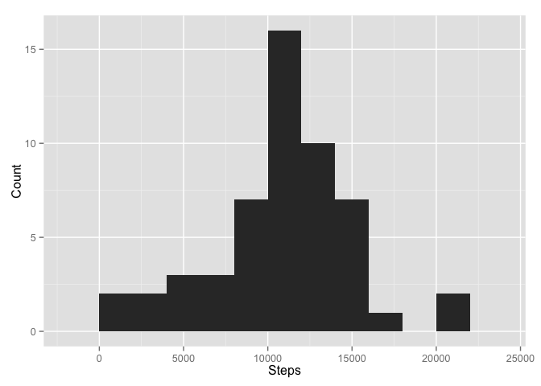

```r
ggplot(dailyActivity, aes(daysteps)) + geom_histogram(binwidth = 2000) +
    labs(x = "Steps") + labs(y = "Count")
```

## What is the average daily activity pattern?

To get the activity pattern the data is re-grouped by interval and then the average number of steps in a given interval is found as well as the interval with the largest number of steps.

```r
intervalActivity <- group_by(activity, interval) %>%
    summarise(meanInterval = mean(steps, na.rm=TRUE))
maxStepInterval <- intervalActivity$interval[which.max(intervalActivity$meanInterval)]
```

Here is the line graph of the daily activity data:

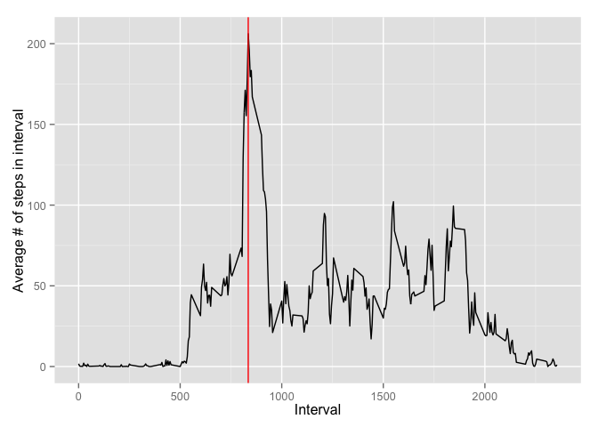

```r
ggplot(intervalActivity, aes(interval, meanInterval)) + geom_line() +
    labs(x = "Interval") + labs(y = "Average # of steps in interval") +
    geom_vline(xintercept = maxStepInterval, colour="red")
```

The red vertial line shows that the interval with the highest average activity is the interval number **835**.

## Imputing missing values

```r
missing <- sum(is.na(activity$steps))
```

The total number of missing values in the dataset is **2304**.

Substitute missing values with averages for a given time interval and store in a new *imputeSteps* variable.

```r
imputedActivity <- group_by(activity, interval) %>%
    mutate(imputeSteps = ifelse(is.na(steps), mean(steps, na.rm=TRUE), steps))
```

To calculate new mean and median stats use the following code, which groups the data by date and then finds the total number of steps in a given day, subsequently calculating the mean and median:

```r
dailyActivityNew <- group_by(imputedActivity, date) %>%
    summarise(daysteps=sum(imputeSteps))
dailyMeanNew <- mean(dailyActivityNew$daysteps, na.rm=TRUE)
dailyMedianNew <- median(dailyActivityNew$daysteps, na.rm=TRUE)
```

The mean total number of steps taken per day is around **10766.19**, while the median is **10766.19**. Here is the histogram of the total number of steps taken per day:

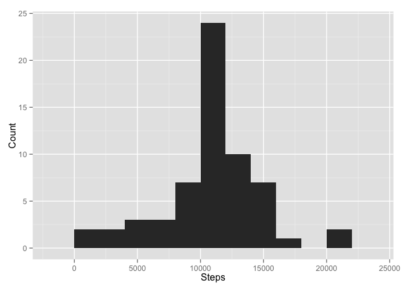

```r
ggplot(dailyActivityNew, aes(daysteps)) + geom_histogram(binwidth = 2000) +
    labs(x = "Steps") + labs(y = "Count")
```

## Are there differences in activity patterns between weekdays and weekends?

Imputed activity data already has additional dayofweek column, thus :

```r
weekdayActivity <- group_by(imputedActivity, interval) %>%
    filter(dayofweek=='weekday') %>%
    summarise(intMean=mean(imputeSteps)) %>%
    mutate(dayofweek='weekday')

weekendActivity <- group_by(imputedActivity, interval) %>%
    filter(dayofweek=='weekend') %>%
    summarise(intMean=mean(imputeSteps)) %>%
    mutate(dayofweek='weekend')

meanIntActivity <- bind_rows(weekdayActivity, weekendActivity)
```

Here is the line graph of the weekend and weekday activity patterns:

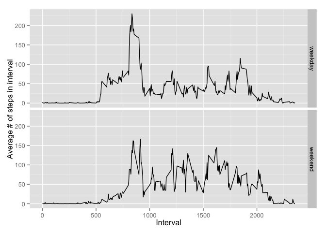

```r
ggplot(meanIntActivity, aes(interval, intMean)) + geom_line() +
    labs(x = "Interval") + labs(y = "Average # of steps in interval") + facet_grid(dayofweek ~ .)
```

The two key differences that are immediately obvious is that on the weekends the activity is low early in the day, most likely because the person starts the weekend days later and with less activity. On the other hand on average there’s a higher number of steps taken during the course of the day, that’s likely because on the weekend there’s no need to sit in the office and the person is more active physically instead of being mostly sitted in front of the computer.